# Exercise solutions: Section 2.10

Rob J Hyndman & George Athanasopoulos

1. Use the help menu to explore what the series `gold`, `woolyrnq` and `gas` represent. These are available in the `forecast` package.

   ```
   ## starting httpd help server ... done
   ```

   1. Use `autoplot` to plot each of these in separate plots.

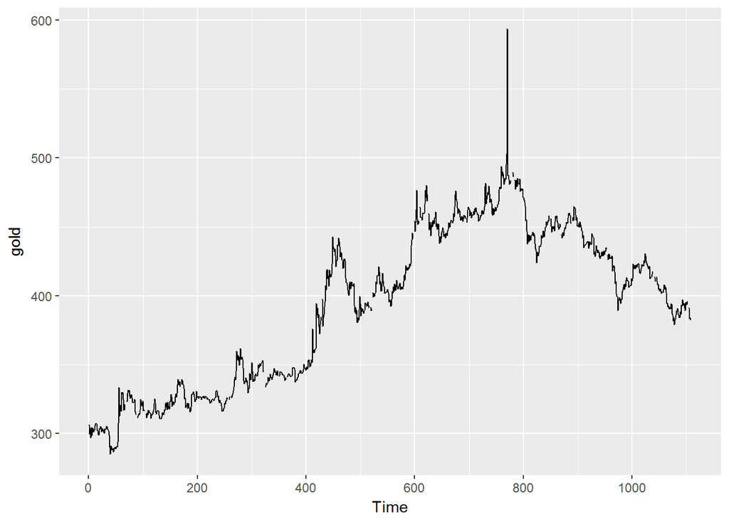

   ```r
   autoplot(gold)
   ```

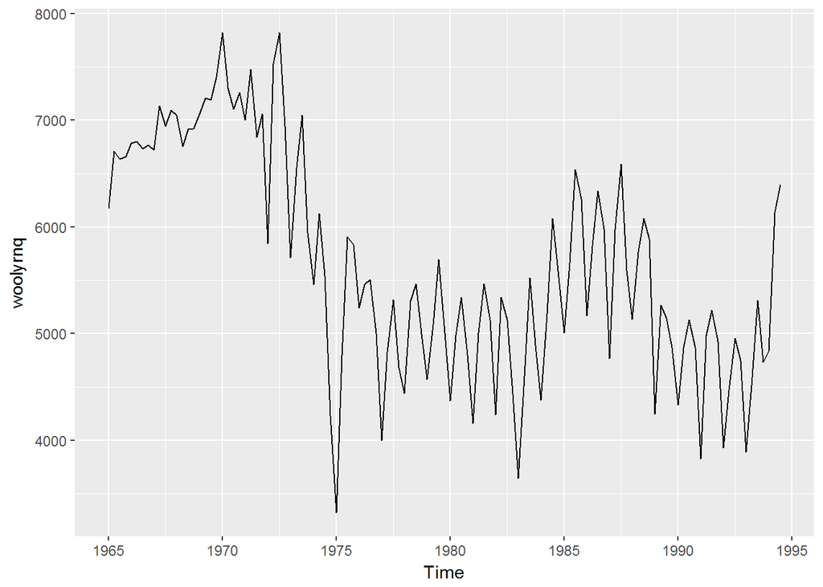

   ```r
   autoplot(woolyrnq)
   ```

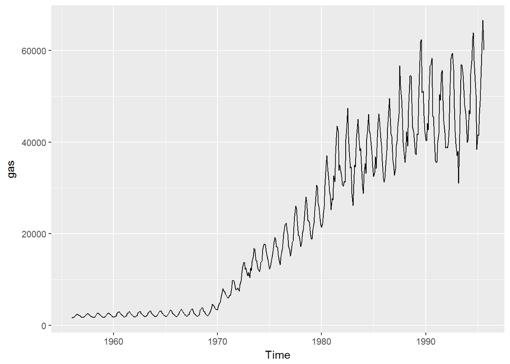

   ```r
   autoplot(gas)
   ```

   2. What is the frequency of each commodity series? Hint: apply the `frequency()` function.

   ```r
   frequency(gold)
   ```

   ```
   ## [1] 1
   ```

   ```r
   frequency(woolyrnq)
   ```

   ```
   ## [1] 4
   ```

   ```r
   frequency(gas)
   ```

   ```
   ## [1] 12
   ```

   3. Use `which.max()` to spot the outlier in the `gold` series. Which observation was it?

   ```r
   which.max(gold)
   ```

   ```
   ## [1] 770
   ```

2. Download the file `tute1.csv` from OTexts.org/fpp2/extrafiles/tute1.csv open it in Excel (or some other spreadsheet application) and review its contents. You should find four columns of information. Columns B through D each contain a quarterly series, labelled Sales, AdBudget and GDP. Sales contains the quarterly sales for a small company over the period 1981-2005. AdBudget is the advertising budget and GDP is the gross domestic product. All series have been adjusted for inflation.
   1. You can read the data into R with the following script:

   ```r
   tute1 <- read.csv("tute1.csv", header=TRUE)
   #View(tute1)
   ```

   2. Convert the data to time series

   ```r
   mytimeseries <- ts(tute1[,-1], start=1981, frequency=4)
   ```

   (The `[,-1]` removes the first column which contains the quarters as we don’t need them now.)
   3. Construct time series plots of each of the three series

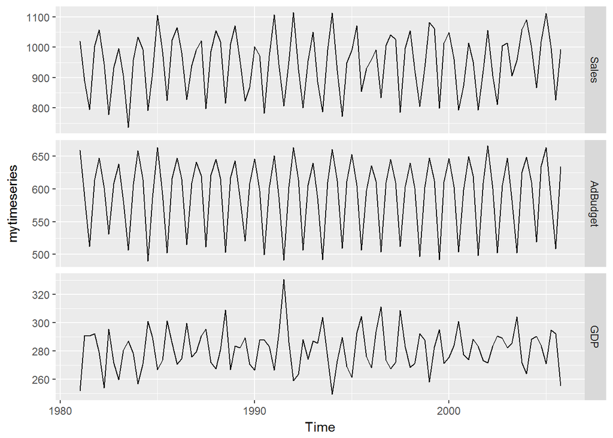

   ```
   Check what happens when you don't include `facets=TRUE`.
   ```

   ```r
   autoplot(mytimeseries, facets=TRUE)
   ```

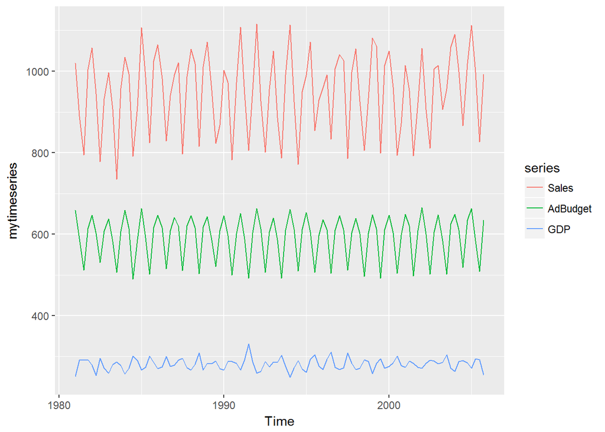

   ```r
   autoplot(mytimeseries)
   ```

3. Download some monthly Australian retail data from OTexts.org/fpp2/extrafiles/retail.xlsx. These represent retail sales in various categories for different Australian states, and are stored in a MS-Excel file.
   1. You can read the data into R with the following script:

   ```r
   retaildata <- readxl::read_excel("retail.xlsx", skip=1)
   ```

   You may need to first install the `readxl` package. The second argument (`skip=1`) is required because the Excel sheet has two header rows.
   2. Select one of the time series as follows (but replace the column name with your own chosen column):

   ```r
   myts <- ts(retaildata[,"A3349873A"], frequency=12, start=c(1982,4))
   ```

   3. Explore your chosen retail time series using the following functions:

      `autoplot`, `ggseasonplot`, `ggsubseriesplot`, `gglagplot`, `ggAcf`

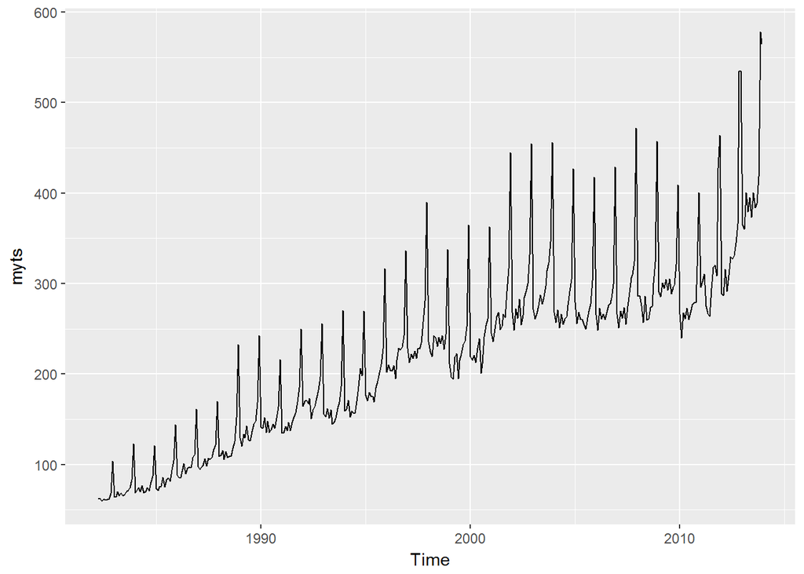

   ```r
   autoplot(myts)
   ```

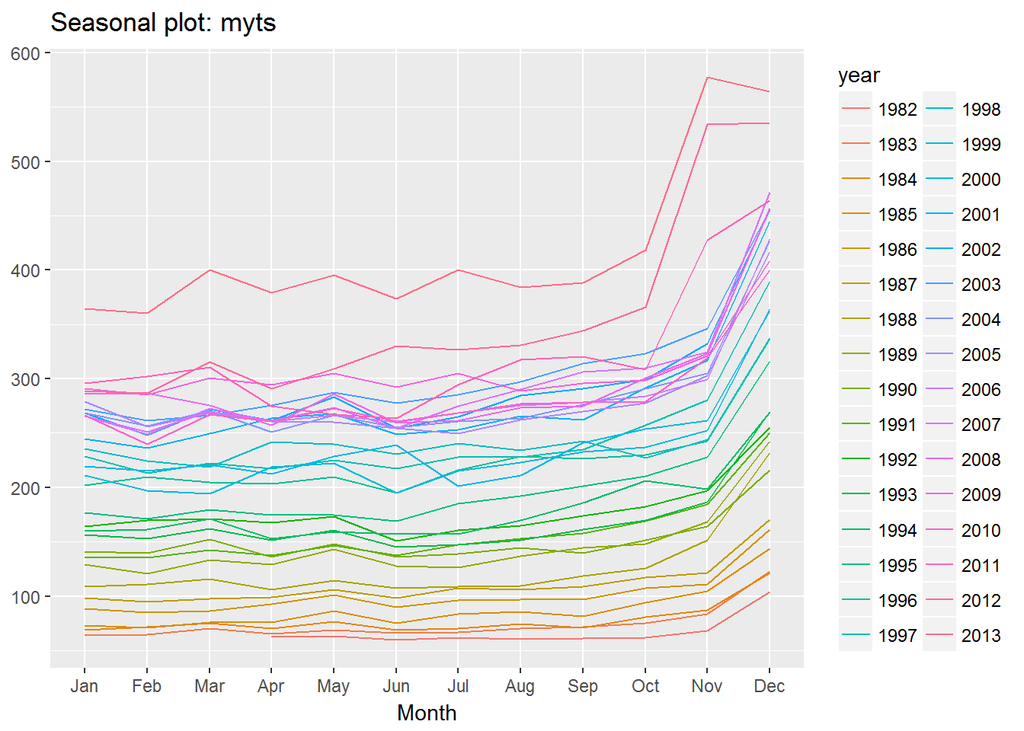

   ```r
   ggseasonplot(myts)
   ```

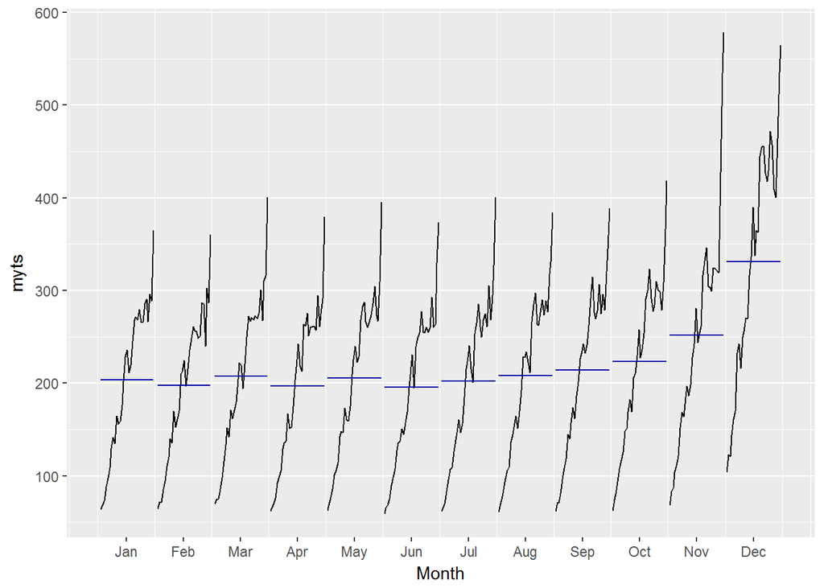

   ```r
   ggsubseriesplot(myts)
   ```

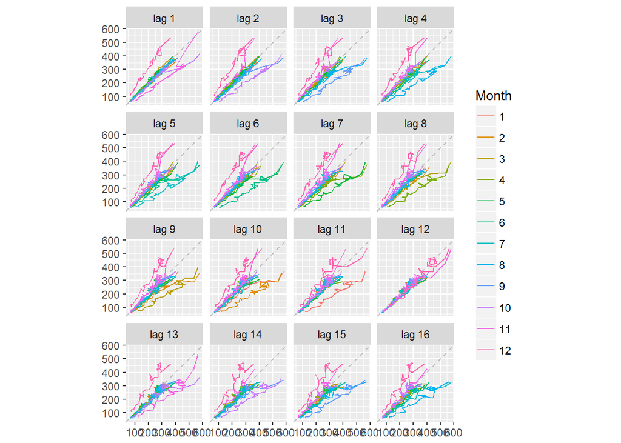

   ```r
   gglagplot(myts)
   ```

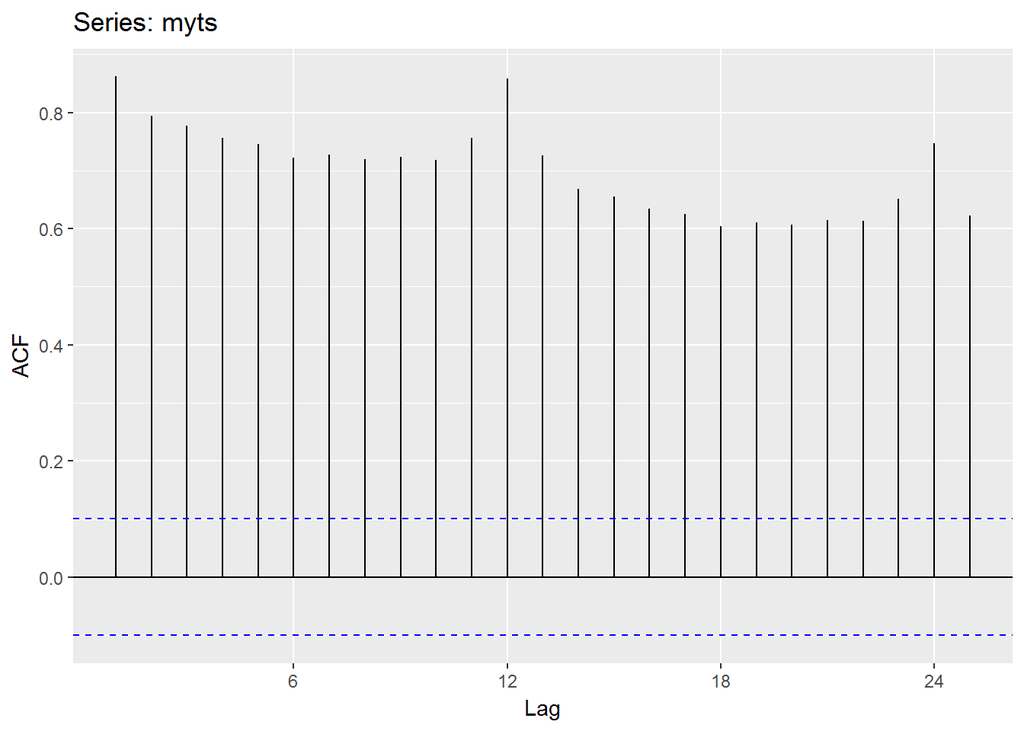

   ```r
   ggAcf(myts)
   ```

   Can you spot any seasonality, cyclicity and trend? What do you learn about the series?
4. Create time plots of the following times series: `bicoal`, `chicken`, `dole`, `usdeaths`, `lynx`, `goog`, `writing`, `fancy`, `a10`, `h02`.
   - Use help() to find out about the data in each series.
   - For the `goog` plot modify the axis labels and title.

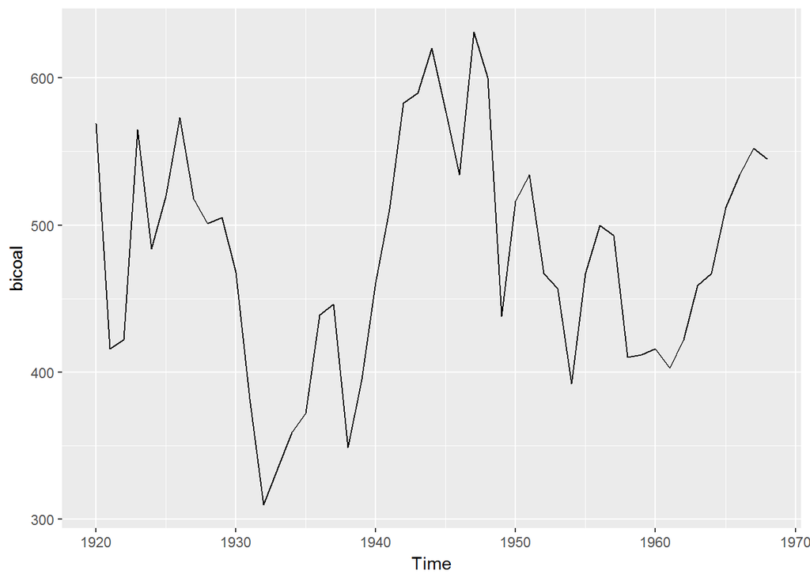

```r
autoplot(bicoal)
```

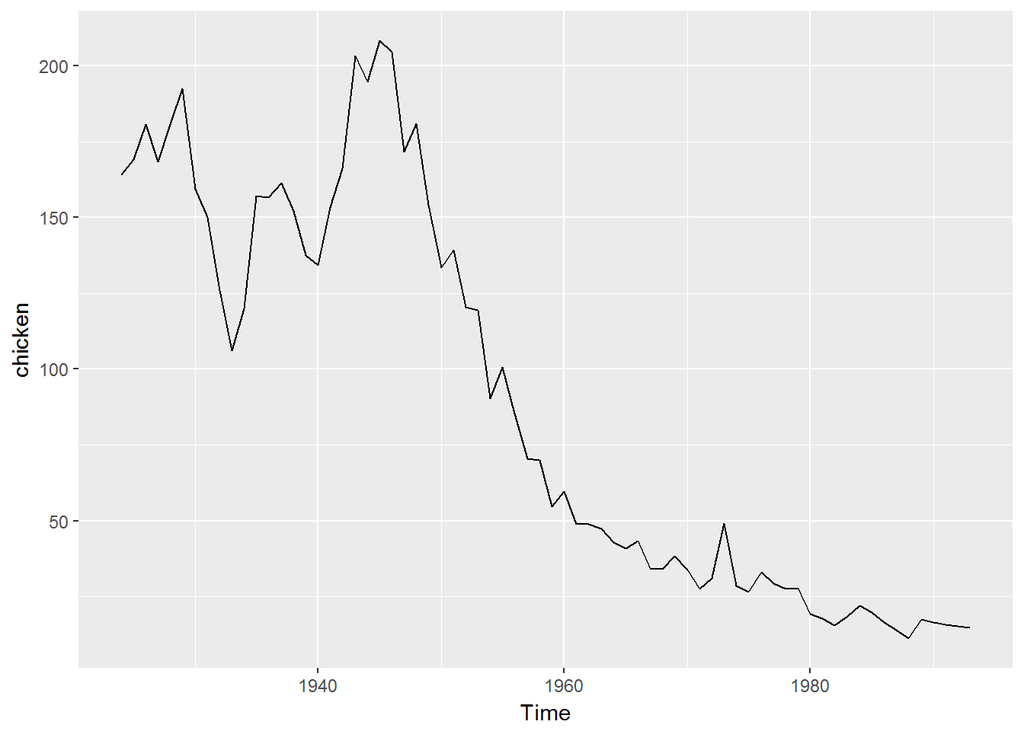

```r
autoplot(chicken)
```

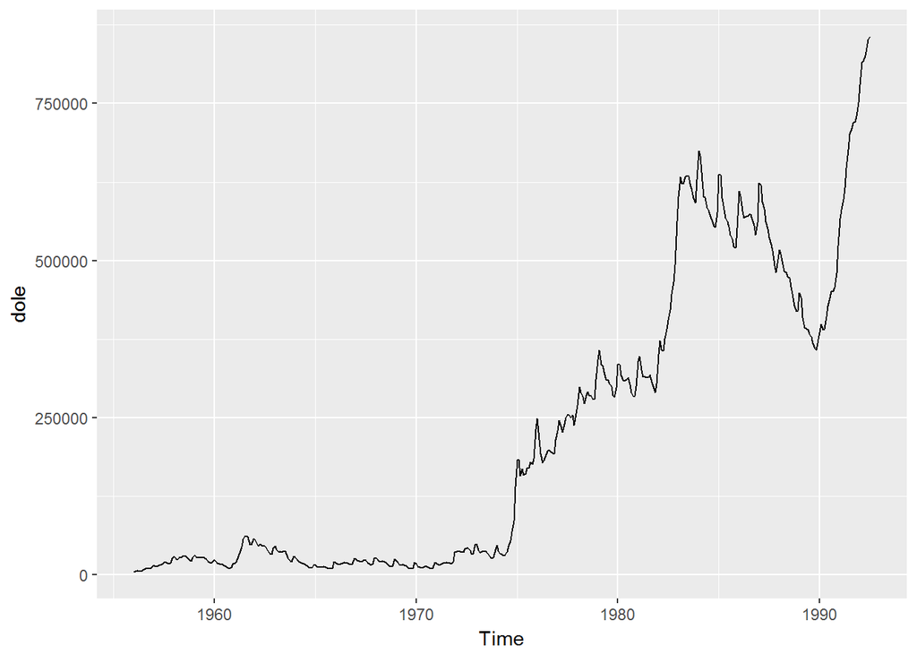

```r
autoplot(dole)
```

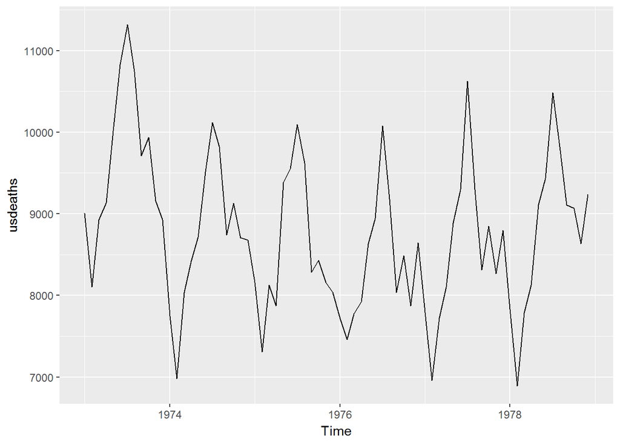

```r
autoplot(usdeaths)
```

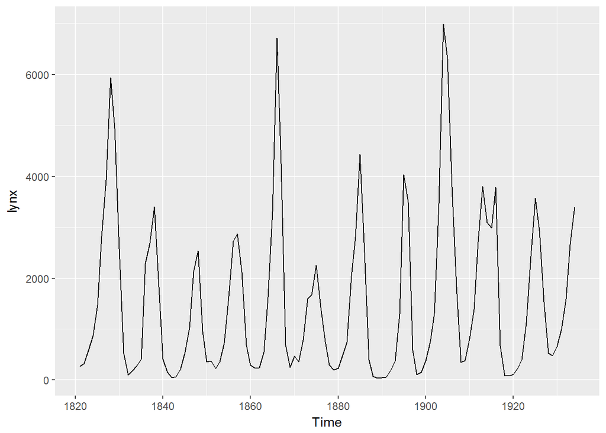

```r
autoplot(lynx)
```

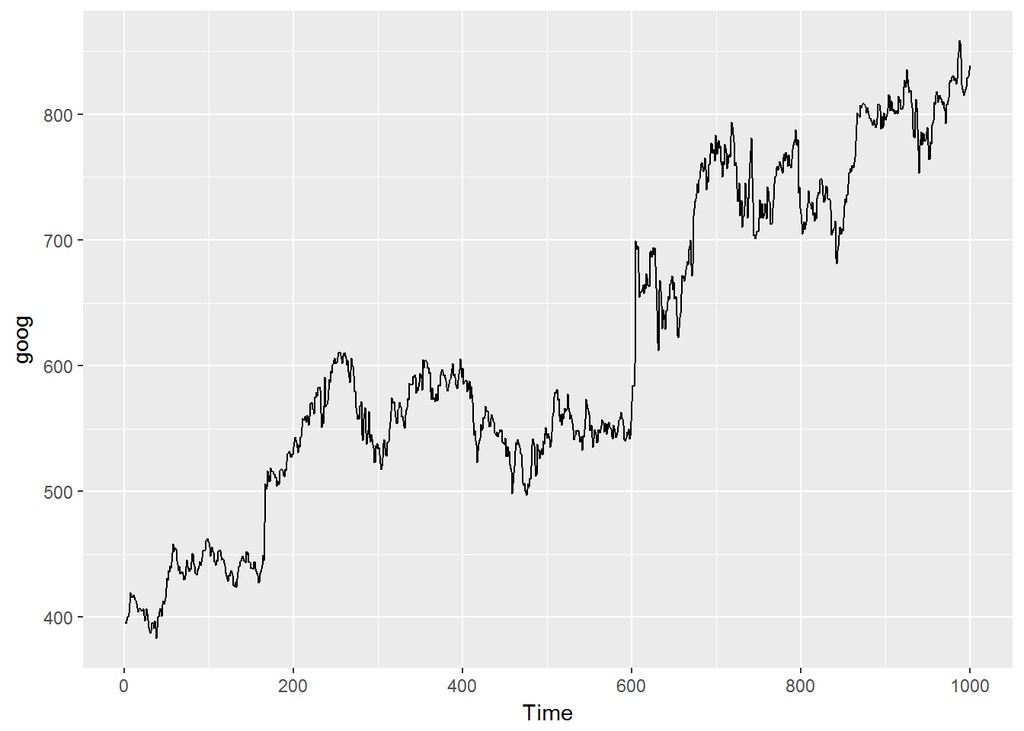

```r
autoplot(goog)
```

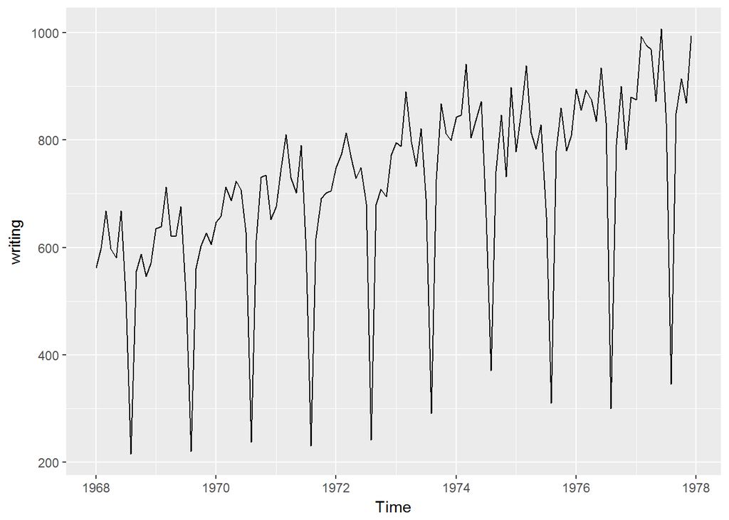

```r
autoplot(writing)
```

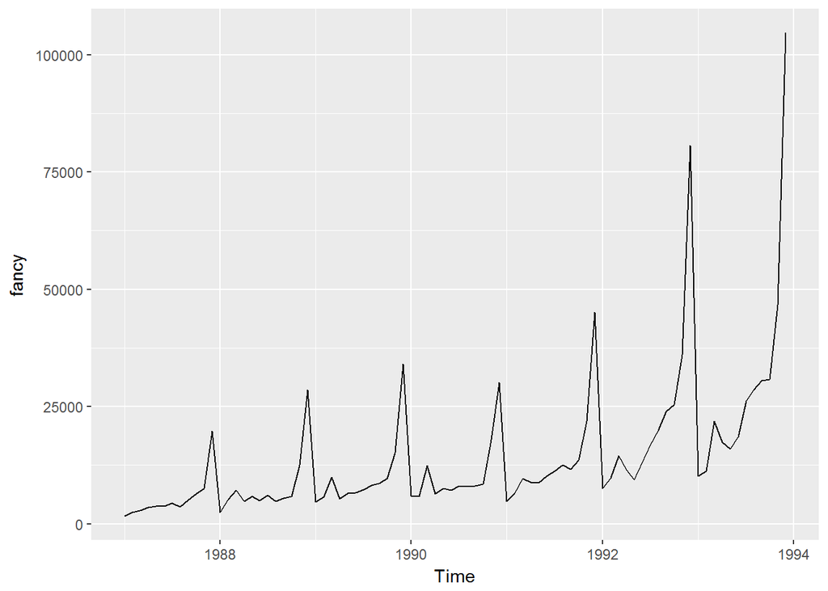

```r
autoplot(fancy)
```

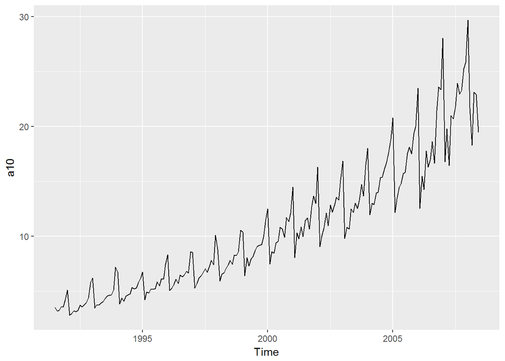

```r
autoplot(a10)
```

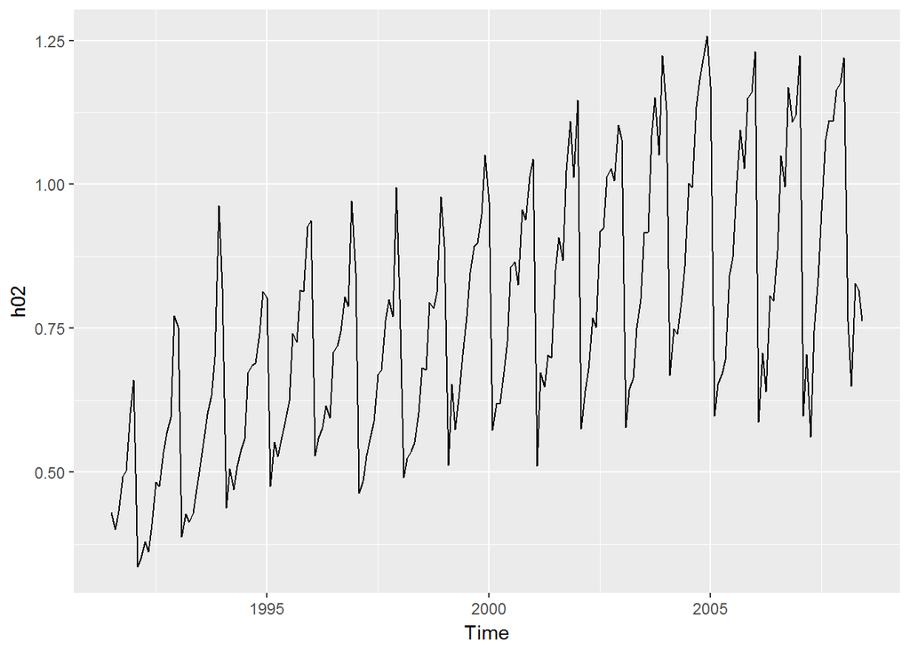

```r
autoplot(h02)
```

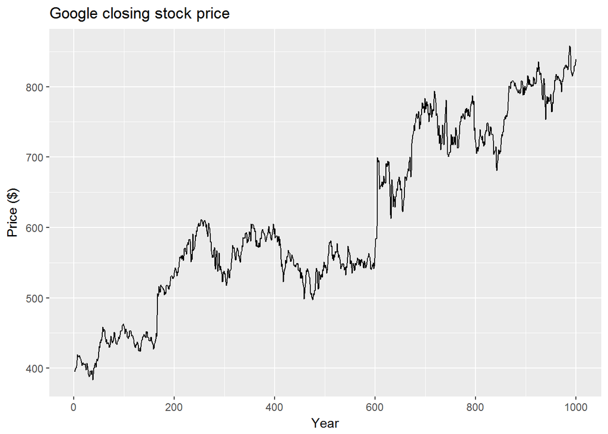

```r
autoplot(goog)+
  xlab("Year") + ylab("Price ($)") +
  ggtitle("Google closing stock price")
```

5. Use the `ggseasonplot` and `ggsubseriesplot` functions to explore the seasonal patterns in the following time series: `writing`, `fancy`, `a10`, `h02`.
   - What can you say about the seasonal patterns?
   - Can you identify any unusual years?

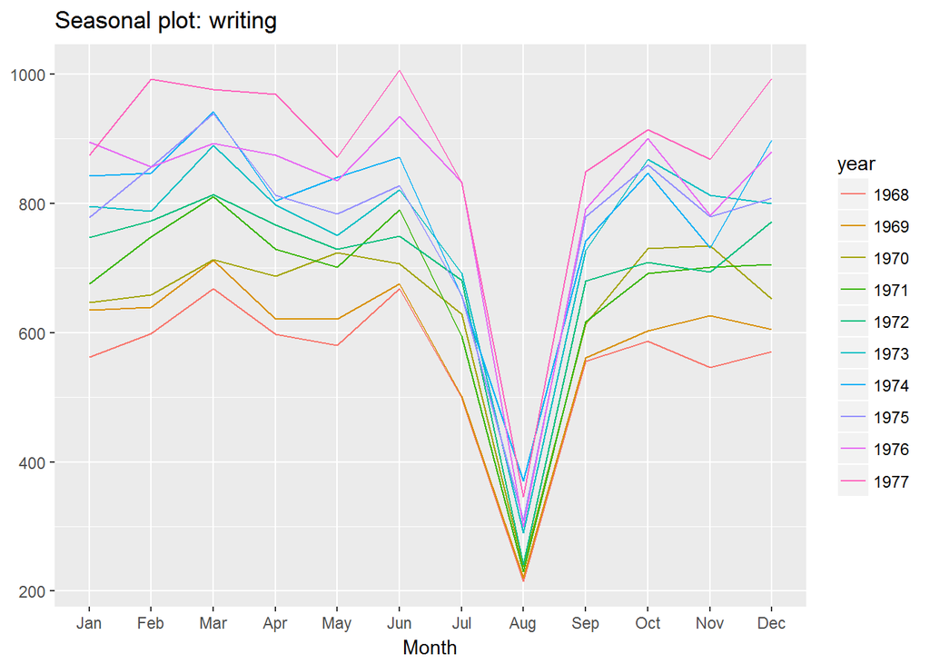

```r
ggseasonplot(writing)
```

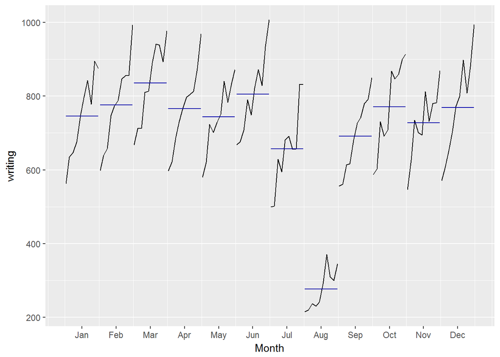

```r
ggsubseriesplot(writing)
```

- August is very low compared to other months (a summer vacation effect in France)
- Otherwise weak seasonality
- No obviously unusual years

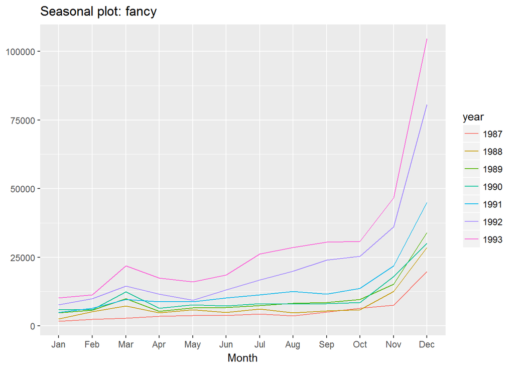

```r
ggseasonplot(fancy)
```

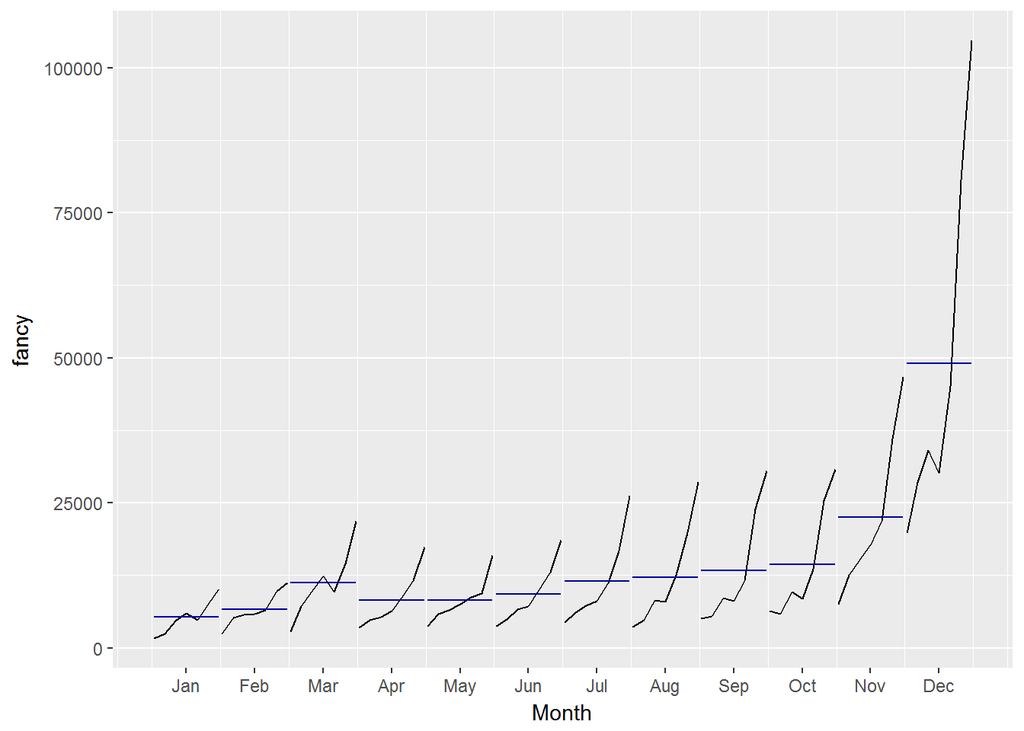

```r
ggsubseriesplot(fancy)
```

- December is much higher than the other months, presumably due to summer holidays in Queensland, or possibly Christmas.
- The last few years show much higher sales than previous years, but this is probably just due to the exponential trend in the data.

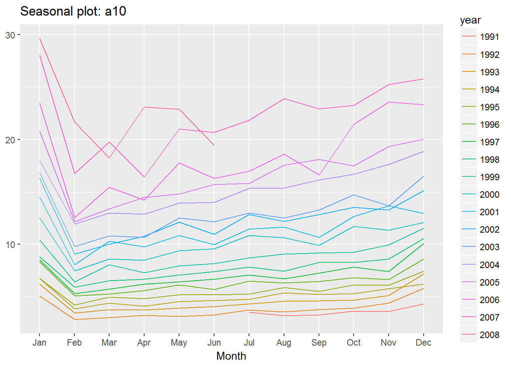

```r
ggseasonplot(a10)
```

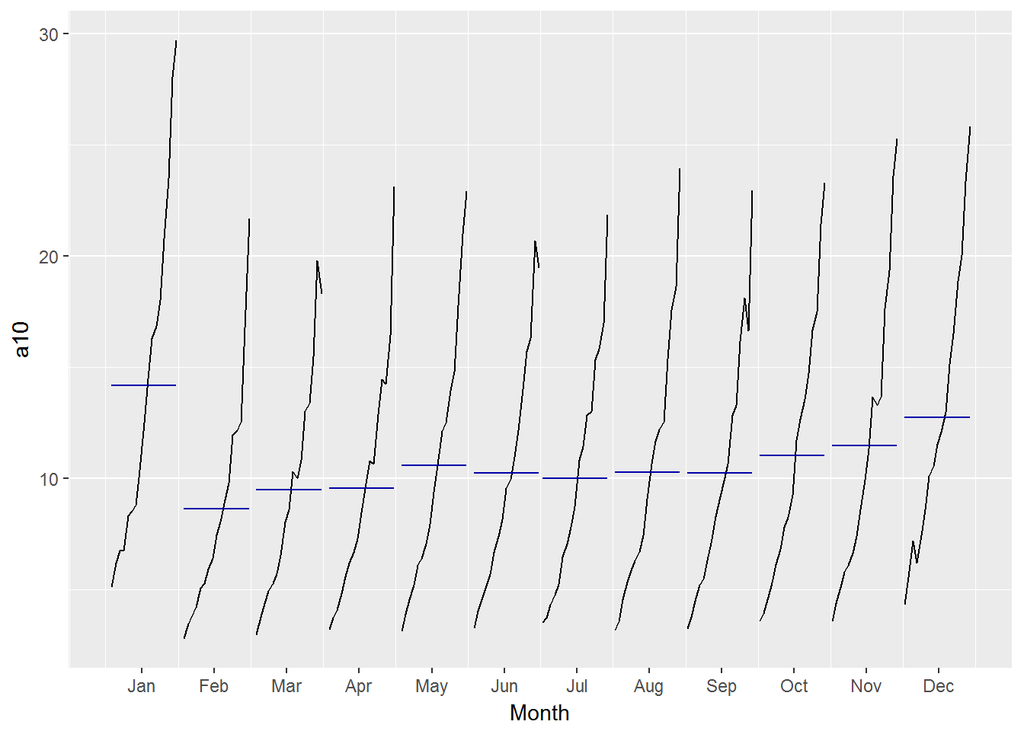

```r
ggsubseriesplot(a10)
```

- seasonality jumps in January, falls in February, then slowly increases through the year.
- Feb-Mar-Apr pattern of down-up-down probably due to month lengths
- 2008 reverses the pattern

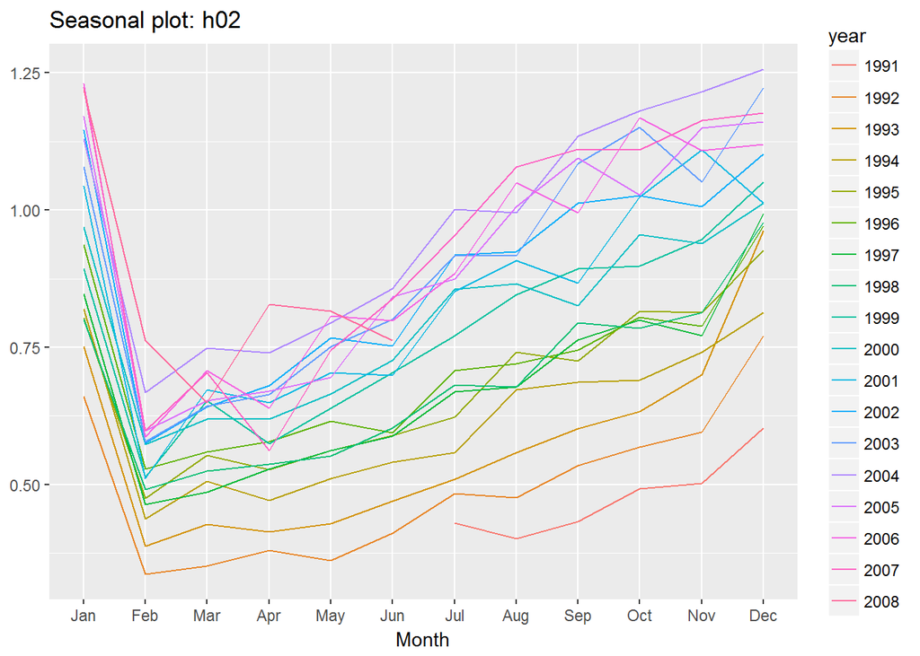

```r
ggseasonplot(h02)
```

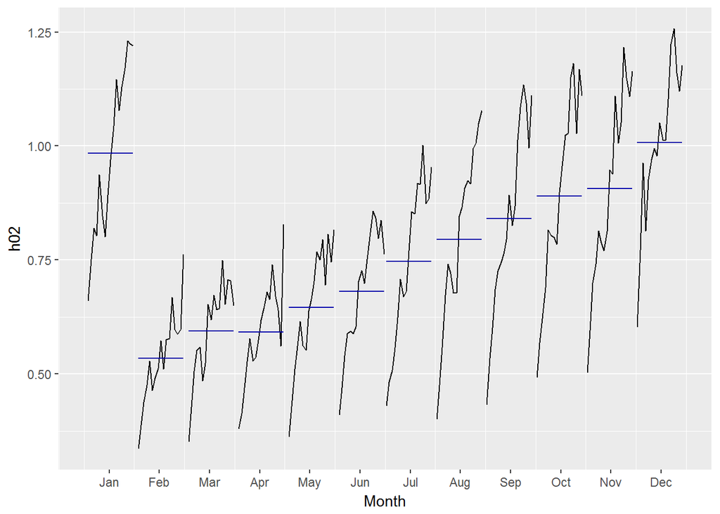

```r
ggsubseriesplot(h02)
```

- seasonality jumps in January, falls in February, then slowly increases through the year.
- Feb-Mar-Apr pattern of down-up-down probably due to month lengths
- 2008 (and 1997?) reverses the pattern
6. Use the the following graphics functions: `autoplot`, `ggseasonplot`, `ggsubseriesplot`, `gglagplot`, `ggAcf` and explore features from the following time series: `hsales`, `usdeaths`, `bricksq`, `sunspotarea`, `gasoline`.
   - Can you spot any seasonality, cyclicity and trend?
   - What do you learn about the series?

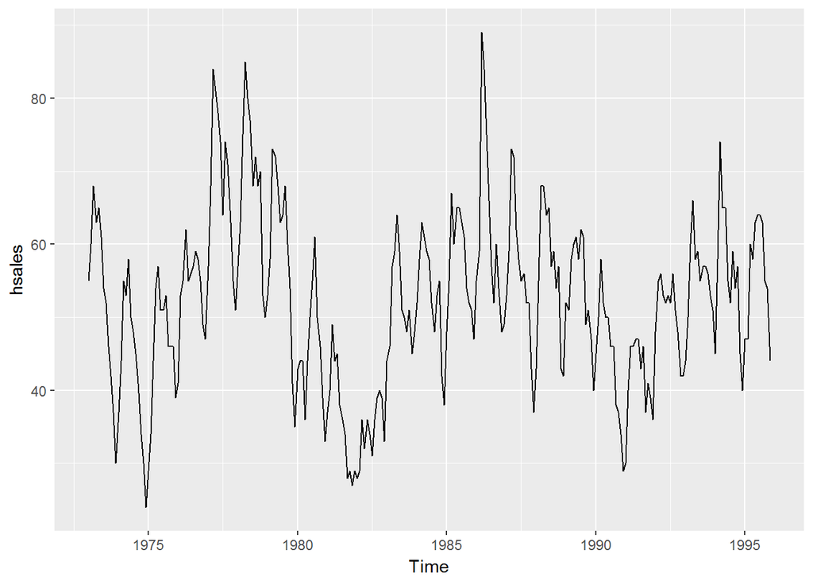

```r
autoplot(hsales)
```